# Charles Zheng Homework 3

## Computation

Consider a CAR model, with a weight matrix \(W\) which is not necessarily symmetric and has zero diagonal. Let \(\tilde{W}\) denote the lower triangle of \(W\). We have \[ \frac{p(\epsilon)}{p(0)} = \exp\left(-\frac{1}{2\tau^2} \epsilon^T (I - 2\phi \tilde{W}) \epsilon\right) \] which is equivalent to \[ \frac{p(\epsilon)}{p(0)} = \exp\left(-\frac{1}{2\tau^2} \epsilon^T (I - \phi (\tilde{W} + \tilde{W}^T)) \epsilon\right). \] Since \(\tilde{W} + \tilde{W}^T\) is symmetric, we might as well assume that \(W\) is symmetric. Hence \[ \epsilon \sim N(0, \tau^2(I - \phi W)^{-1}) \] Now suppose \[ W = V D V^T. \] Then \[ \tau^2 (I - \phi W)^{-1} = \tau^2 V (I - \phi D)^{-1} V^T \]

## Model

Since we have Poisson data, we use the model \[ y \sim Poisson(e^{X\beta + \epsilon}) \] where \[ \epsilon \sim N(0, \tau^2(I - \phi W)^{-1}) \] Here the model is no longer a CAR model due to the Poisson transformation. Instead, \(\epsilon\) act as latent variables which induce spatial correlation.

```r
library(maptools)
library(RColorBrewer)
library(classInt)
library(magrittr)
library(spdep)
library(pracma)
```

## Loading the data

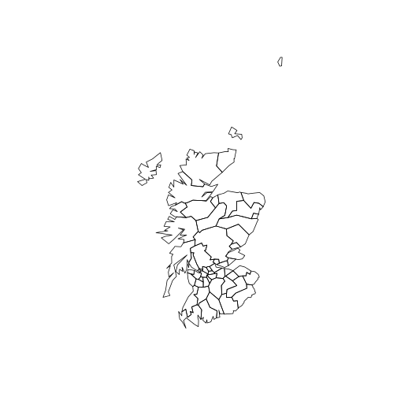

```r
shapes <- readShapeSpatial("scotlip/scotlip.shp")
plot(shapes)
```

```r
nb <- poly2nb(shapes)
W <- nb2mat(nb, zero.policy=TRUE)
W2 <- (W * lower.tri(W)) %>% {. + t(.)}
V <- res$vectors
d <- res$values
y <- shapes@data$CANCER
X <- shapes@data %$% cbind(POP, CEXP, AFF, AREA, PERIMETER)
X[, "POP"] <- log(X[, "POP"])
X[, "CEXP"] <- log(X[, "CEXP"])
X[, "AREA"] <- log(X[, "AREA"])
X[, "PERIMETER"] <- log(X[, "PERIMETER"])
dim(X)
```

```
## [1] 56  5
```

```r
n <- dim(W)[1]
```

## Models

Model file

```
data {
  for (i in 1:n) {
    zeros[i] <- 0
  }
}

model {
  phi ~ dunif(0, 0.9)
  tau ~ dgamma(2, 100)
  tau2 ~ dgamma(2, 100)
  beta0 ~ dnorm(0, tau2)
  for (i in 1:p) {
    beta[i] ~ dnorm(0, tau2)
  }
  eps[] ~ dmnorm(zeros[], T[ , ])
  for (i in 1:n) {
    mu[i] <- exp(inprod(X[i, 1:p], beta[]) + beta0 + eps[i])
    y[i] ~ dpois(mu[i])
  }
  for (i in 1:n) {
    for (j in 1:n) {
      Wt[i,j] <- pow(tau, 2)/(1 - phi * d[j]) * Vt[i, j]
    }
  }
  for (i in 1:n) {
    for (j in 1:n) {
      T[i, j] <- inprod(V[i,1:n],Wt[1:n,j])
    }
  }
}
```

Intializing model…

```r
model <- jags.model("pois_sp.bug", data=list(eps = rnorm(56), d = d, n = 56,
                                             V = V, Vt = t(V), y = y, X = X, p = 5),
                    inits = list(phi = 0.2, tau = 2, tau2 = 2,
                                 beta0 = 0, beta = rep(0, 5)), n.chains = 5)
```

Draw samples

```r
#out <- coda.samples(model, c("phi", "mu", "beta"), n.iter = 100000)
#save(out, file="~/out.RData")
load("~/out.RData")
```

### Diagnostics

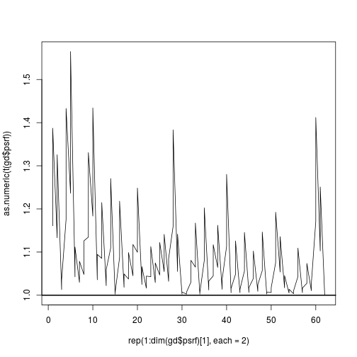

```r
gd <- gelman.diag(out)
plot(rep(1:dim(gd$psrf)[1], each = 2), as.numeric(t(gd$psrf)), type = "l")
abline(a=1, b = 0, lwd = 2)
```

Does not converge even with 100000 iterations.

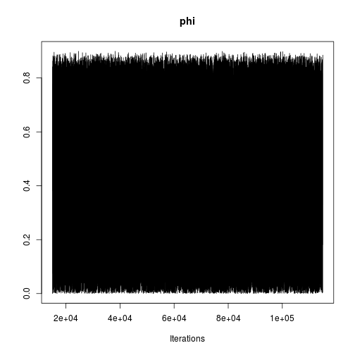

```r
traceplot(out[[1]][, "phi"], main = "phi")
```

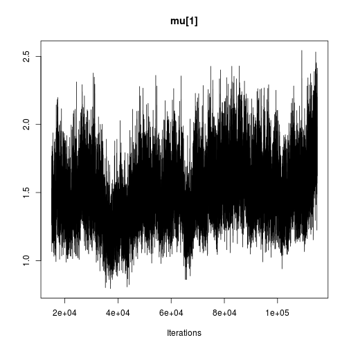

```r
traceplot(out[[1]][, "mu[1]"], main = "mu[1]")
```

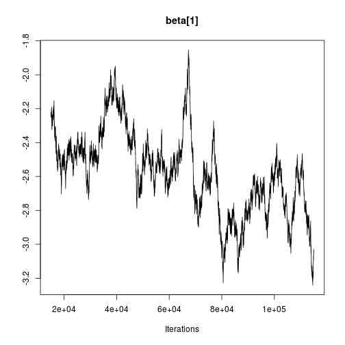

```r
traceplot(out[[1]][, "beta[1]"], main = "beta[1]")
```

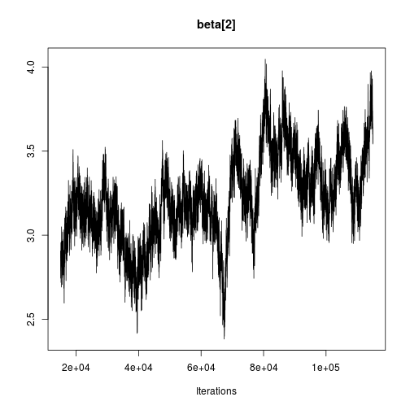

```r
traceplot(out[[1]][, "beta[2]"], main = "beta[2]")
```

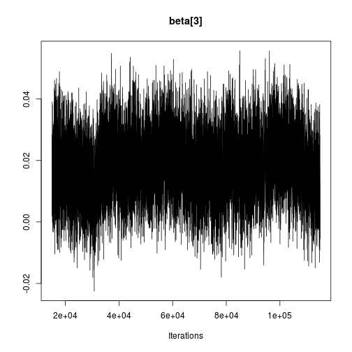

```r
traceplot(out[[1]][, "beta[3]"], main = "beta[3]")
```

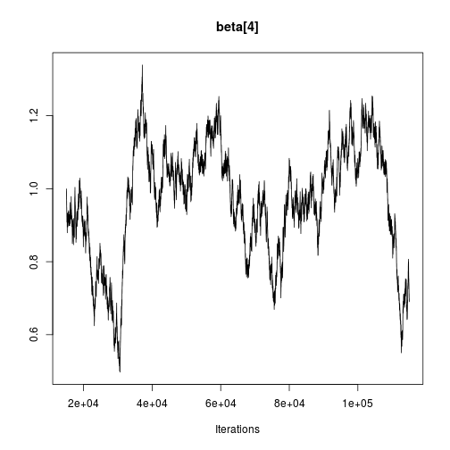

```r
traceplot(out[[1]][, "beta[4]"], main = "beta[4]")
```

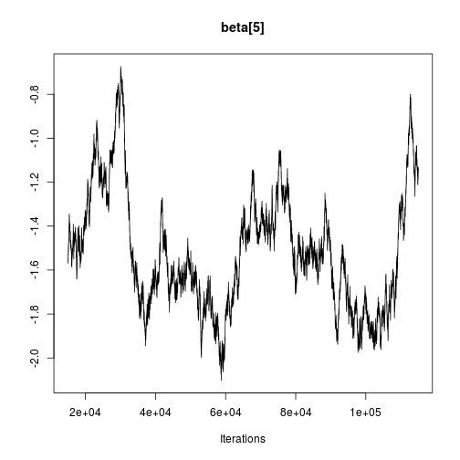

```r
traceplot(out[[1]][, "beta[5]"], main = "beta[5]")
```

Traceplots look good expect for \(\beta\)…

### Posterior

We look at the posterior fitted values

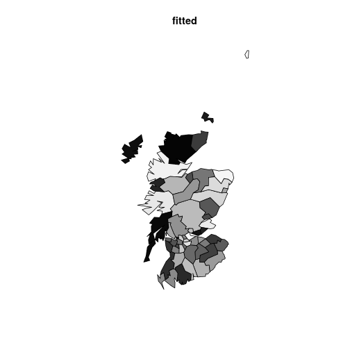

```r
pmu <- out[[1]][, paste0("mu[", 1:56, "]")]
sd <- SpatialPolygonsDataFrame(shapes, shapes@data)
plot(sd["CANCER"], col = gray(1:56/56)[order(pmu[10000, ])], main = "fitted")
```

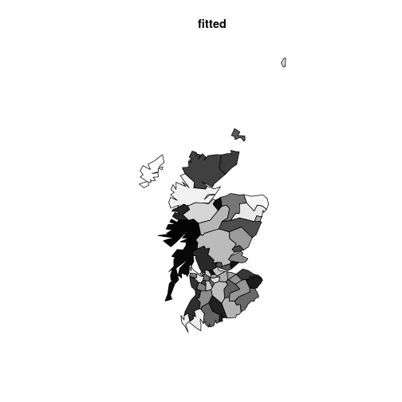

```r
plot(sd["CANCER"], col = gray(1:56/56)[order(pmu[20000, ])], main = "fitted")
```

Posterior residuals, defined as \((y - \mu)/sqrt(\mu)\)

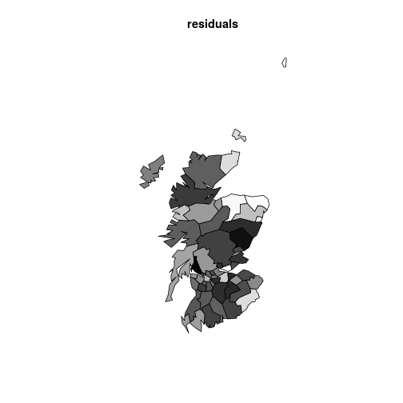

```r
resid <- t(y - t(pmu))/sqrt(pmu)
st_resid <- resid %>% {(. - mean(.))/sd(.)}
plot(sd["CANCER"], col = gray(pnorm(st_resid[10000, ])), main = "residuals")
```

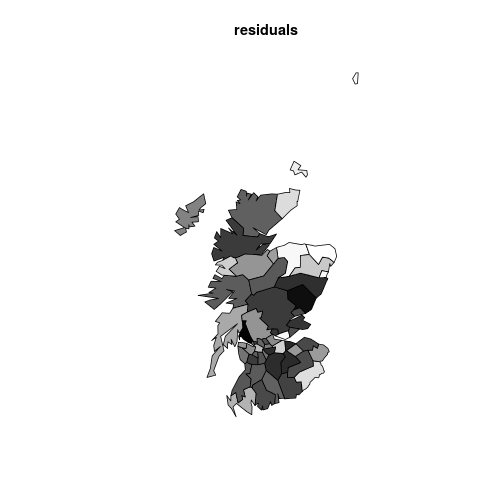

```r
plot(sd["CANCER"], col = gray(pnorm(st_resid[50000, ])), main = "residuals")
```

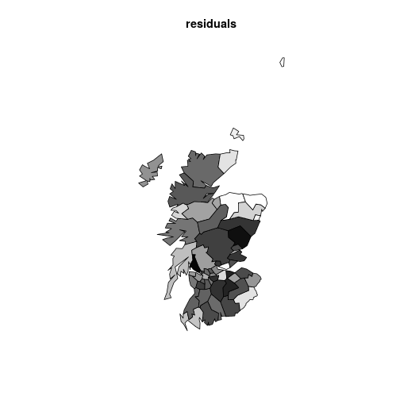

```r
plot(sd["CANCER"], col = gray(pnorm(st_resid[90000, ])), main = "residuals")
```

There is still spatial correlation in the residuals!